# RNA-seq KO Analysis

Michael Kelly

01/20/2022

# CRISPR KO Analysis Workflow; SE 60 (2v2 "toy" example using real data)

# RNA Data Pre-Processing (Unix Environment)

First the raw data was combined into into a single matrix using UNIX tools.

```
paste OV3_WT-2-57925410-201215_NS500276_0197_AH7KV7BGXH_TCTCTACT-CGCGGTTC_S11.read_counts.txt OV3_WT-3-57925410-201215_NS500276_0197_AH7KV7BGXH_GACCTGAA-TTGGTGAG_S10.read_counts.txt OV3_SE60-12-57925408-201215_NS500276_0197_AH7KV7BGXH_ATCCACTG-AGGTGCGT_S5.read_counts.txt OV3_SE60-54-57925409-201215_NS500276_0197_AH7KV7BGXH_CAAGCTAG-ACATAGCG_S7.read_counts.txt > outputfile.txt
```

This makes a file where we have the entrez gene id and symbol for every sample so I needed to cut it down

To keep entrez and symbol with counts we cut certain columns; I keep the entrez id, the symbol, then the counts for WT1,2 and SE60KO 1,2

```
cut -f 1,2,3,6,9,12 outputfile.txt > OV3_WT_SE60_Read_Counts_w_Entrez.txt
```

I next remove the entrez id as the gene symbol is okay for counting and DESEQ2

```
cut -f 2,3,4,5,6 OV3_WT_SE60_Read_Counts_w_Entrez.txt > OV3_WT_SE60_Symbol_Read_Counts.txt
```

Then I remove any non-unique lines and sort the file

```
sort -u -k1,1 OV3_WT_SE60_Symbol_Read_Counts.txt > Unique_WT_SE60_Symbol_counts.txt
```

Lastly I use a text editor like vi to enter the output file and remove the first four lines (the counting statistics from htseq) and add column names giving me my input file

```
head Unique_WT_SE60_Symbol_counts.txt
Symbol  WT1 WT2 SE60KO1 SE60KO2
A1BG    12  13  42  66
A1BG-AS1    159 144 170 142
A1CF    0   0   0   0
A2M 2   3   5   8
A2M-AS1 10  7   18  3
A2ML1   3   4   2   5
A2ML1-AS1   1   0   0   2
A2ML1-AS2   0   0   0   0
A2MP1   46  40  75  60
```

# CRISPR-KO Analysis (SE14 Full Dataset aka 3 WT controls and 4 KOs)

# Import Data and begin processing

1. First I want to import our data and look at it's structure to ensure I understand its format and that it contains all the information I want

```r
x <- read.delim("SE14_WT3_44_44_5_35_unique_V2.txt",row.names="Symbol")
#x <- read.delim("SE60_WT3_12_54_3.1.2_unique.txt",row.names="Symbol")

x[1:10,]
```

```
##           WT1 WT2 WT3 KO44r2 KO44r1 KO5 KO35
## A1BG       28  12  13     22     47  87   87
## A1BG-AS1  211 159 144    256    260 104  129
## A1CF        0   0   0      0      0   0    0
## A2M         8   2   3      8     14   8    4
## A2M-AS1    13  10   7      8     29   0    3
## A2ML1       4   3   4      3      5   0    0
## A2ML1-AS1   2   1   0      1      3 135  102
## A2ML1-AS2   1   0   0      0      0   0    0
## A2MP1      46  46  40     69     48 107  106
## A3GALT2     5   9  10      8     14   4    3
```

I next want to remove all genes with no counts across my samples as they will cause issues with normalization and variance adjustments

```r
x.sub<- x[rowSums(x) >1 ,]
dim(x)
```

```
## [1] 57133     7
```

```r
dim(x.sub)
```

```
## [1] 35233     7
```

As can be seen we remove about 20k features that had 0 counts

Next I want to create a DESEQ data object from this matrix; this will be done by creating group assignments (3 WT 4 KO). Of import, 5 of these libraries were created at the same time and the other two came later, as such I think it is important to make note of this information. I will encode this as "batch".

```r
group <- factor(c('CNTRL','CNTRL','CNTRL','KO','KO','KO','KO'))
design <- model.matrix(~group)
des<-data.frame(design)
#I like to re-name columns to things that make more sense to me; this will give me a matrix with a sample column and an identity column with 0 for alpha and 1 for beta
des$X.Intercept. <- NULL
des$sample<- as.factor(colnames(x.sub))
des$designation<- as.factor(des$groupKO)
des$groupKO<- NULL
des$batch<-as.factor(c('A','A','A','A','A','B','B'))
des
```

```
##   sample designation batch
## 1    WT1           0     A
## 2    WT2           0     A
## 3    WT3           0     A
## 4 KO44r2           1     A
## 5 KO44r1           1     A
## 6    KO5           1     B
## 7   KO35           1     B
```

I can now use this as to build a condition aware DESEQ dataset

```r
dex<-DESeqDataSetFromMatrix(x.sub,design = ~designation, colData = des)
colnames(dex)<-des$sample
dex
```

```
## class: DESeqDataSet
## dim: 35233 7
## metadata(1): version
## assays(1): counts
## rownames(35233): A1BG A1BG-AS1 ... ZYX ZZEF1
## rowData names(0):
## colnames(7): WT1 WT2 ... KO5 KO35
## colData names(3): sample designation batch
```

```r
design(dex)= ~ 1+batch+designation
```

# Data Exploration: Raw Counts

I next want to explore what this data looks like e.g. how similar are the "replicates", are there outlier effects, whats the high dimension structure, etc.

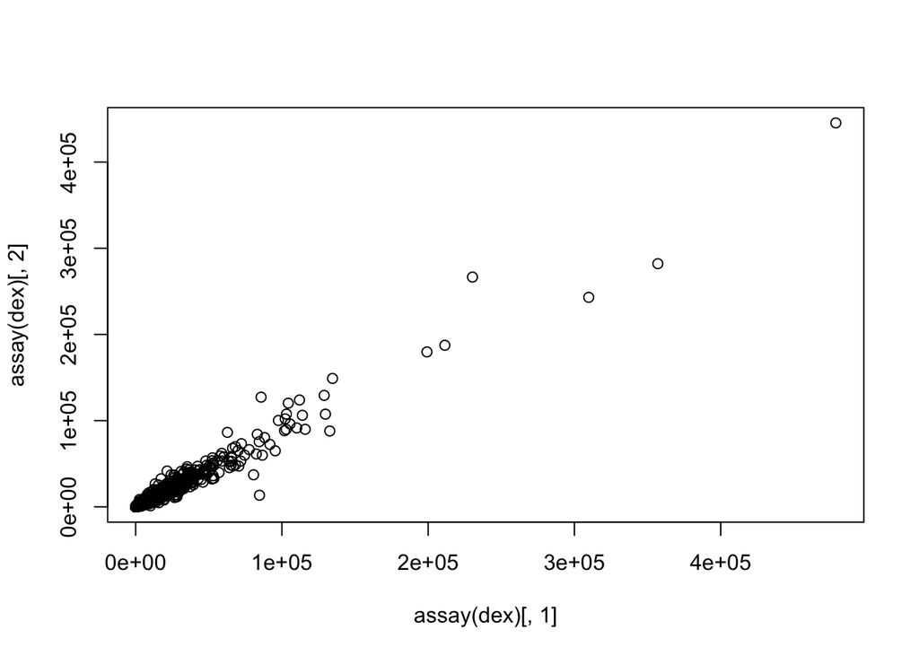

```r
#within WT cells
plot(assay(dex)[,1],assay(dex)[,2])
```

```r
#now looking at correlations of raw data
cor(assay(dex)[,1],assay(dex)[,2])
```

```
## [1] 0.9832419
```

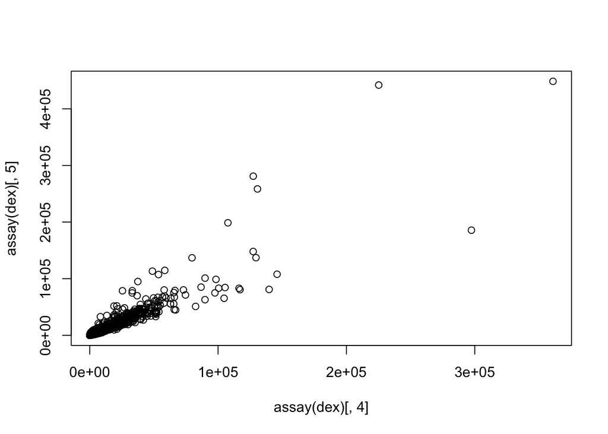

```r
#within KO cells
plot(assay(dex)[,4],assay(dex)[,5])
```

```r
#now looking at correlations
cor(assay(dex)[,4],assay(dex)[,5])
```

```
## [1] 0.9328824
```

# Takeaway pre-normalized Data

We can clearly see that there is a some inter-group variation in the raw-count space; this is not suprising however as we have not adjusted for sequencing depth or performed any kind of scaling. This data will be normalized through the DESEQ2 differential expression analysis pipeline; however, for investigation and visualization purposes the VST transformation is a good surrogate for what goes on under the hood in DESEQ2.

```r
colSums(assay(dex))
```

```
##      WT1      WT2      WT3   KO44r2   KO44r1      KO5     KO35
## 45184617 40296204 35011842 42054673 44455859 29064188 26336590
```

# Data Exploration post VST Normalization

I can now look at if normalizing via a method such as VST can improve some of these issues. In theory VST should adjust for outliers, sequencing depth, and differences in variance structure drastically improving the correlations between our samples and making comparisons much cleaner.

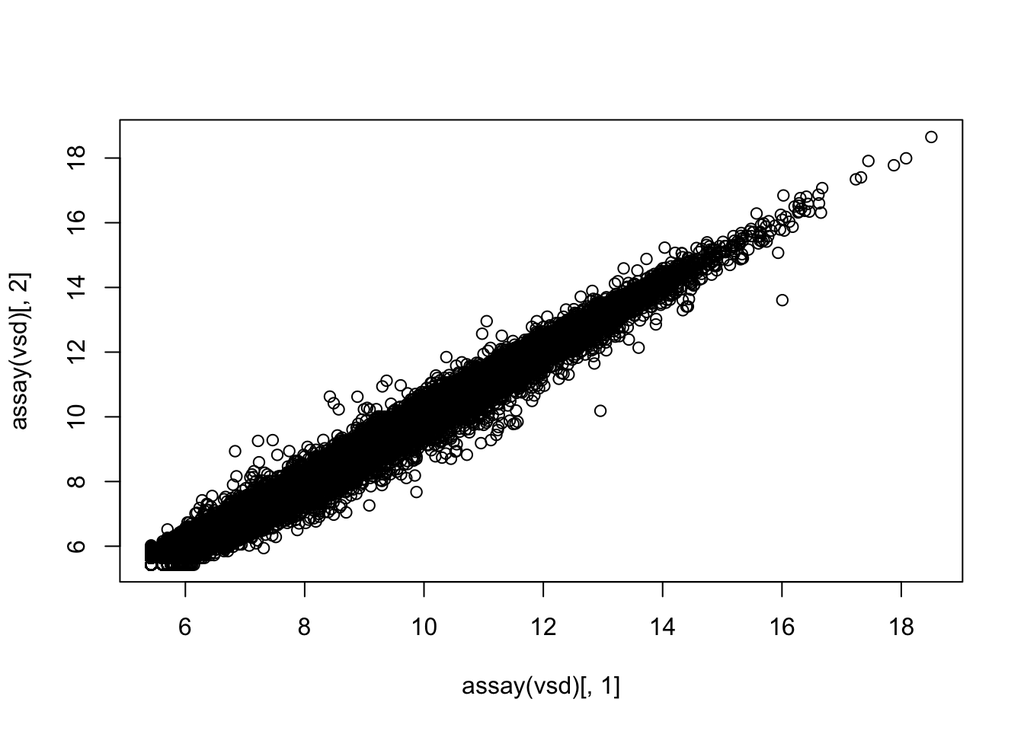

```r
vsd <- vst(dex)

#WT Cells
plot(assay(vsd)[,1],assay(vsd)[,2])
```

```r
cor(assay(vsd)[,1],assay(vsd)[,2])
```

```
## [1] 0.9941299
```

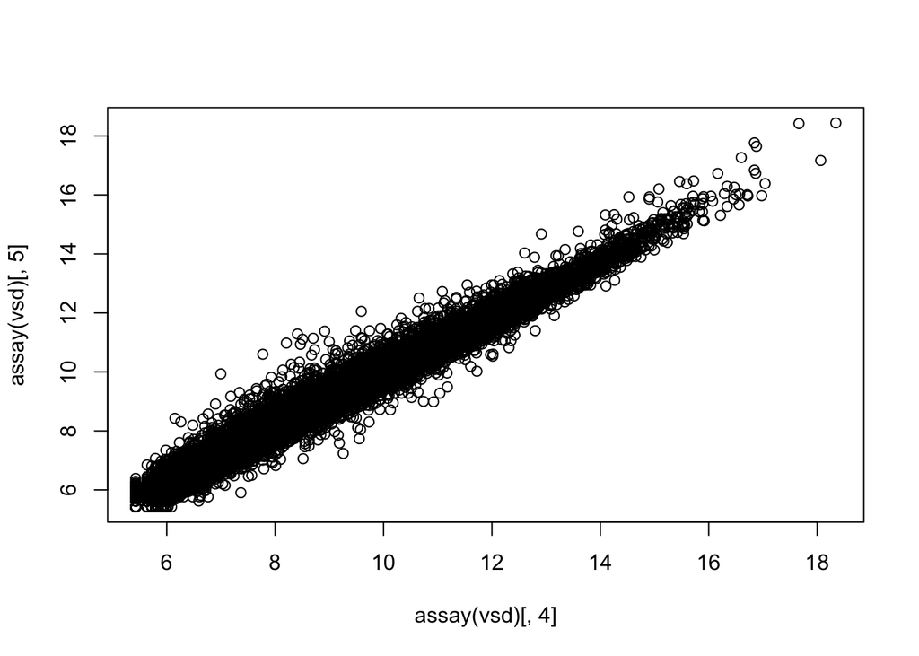

```r
#KO Cells
plot(assay(vsd)[,4],assay(vsd)[,5])
```

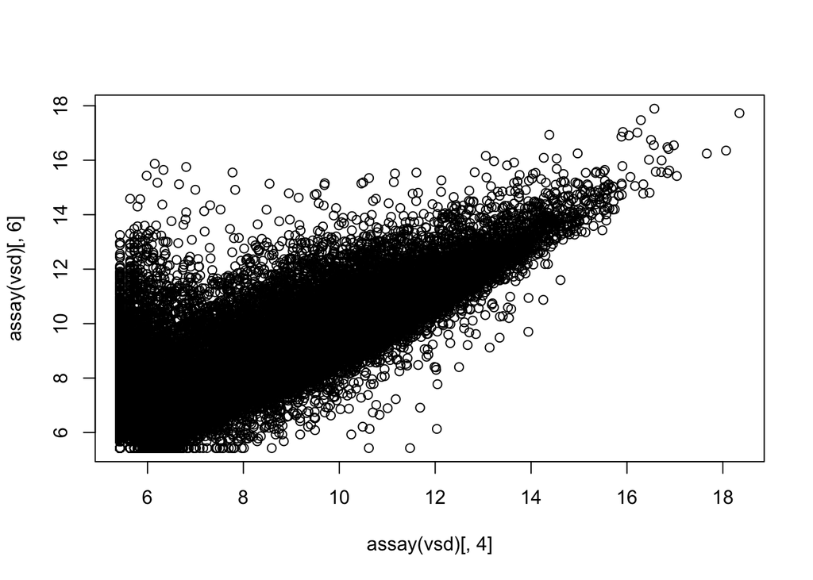

```r
plot(assay(vsd)[,4],assay(vsd)[,6])
```

```r
cor(assay(vsd)[,4],assay(vsd)[,5])
```

```
## [1] 0.9926713
```

```r
cor(assay(vsd)[,4],assay(vsd)[,6])
```

```
## [1] 0.8675778
```

From this analysis we can determine that these samples are closer to their "replicates" now than they were prieviously; while the wild-type is almost perfectly correlated there appears to be some differences KO clones. This is expected however as these are biologically independant KOs and sample 6/7 are from a different batch.

One way to investigate what is happening in the data is through looking at a low dimension representation of the data such as PCA. PCA will allow us to view the overall data structure and determine if there is sample seperation on biologcal or technical levels, ideally we want PC1 to seperate WT and KO samples as that will be the largest source of varience in the data.

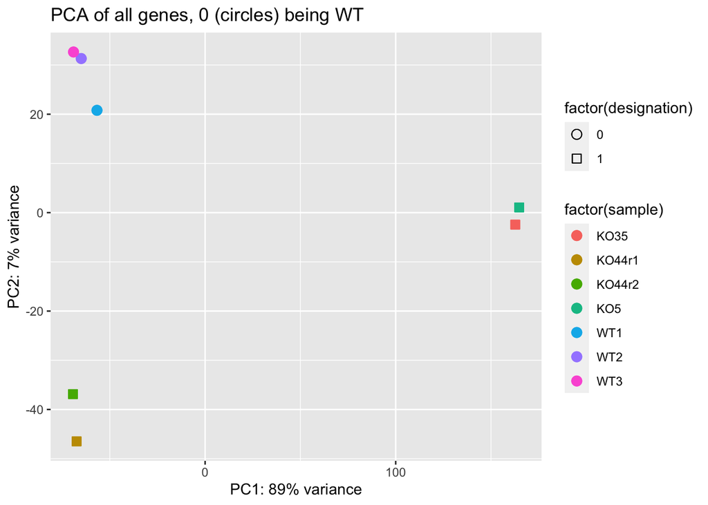

```r
pcaData <-DESeq2::plotPCA(vsd, ntop=20000, intgroup = c("sample","designation") ,returnData = TRUE)

percentVar <- round(100 * attr(pcaData, "percentVar"))
ggplot(pcaData, aes(x = PC1, y = PC2, color = factor(sample), shape = factor(designation))) +
geom_point(size =3, aes(fill=factor(sample))) +
geom_point(size =3) +
scale_shape_manual(values=c(21,22)) +
scale_alpha_manual(values=c("F"=0, "M"=1)) +
xlab(paste0("PC1: ", percentVar[1], "% variance")) +
ylab(paste0("PC2: ", percentVar[2], "% variance")) +
ggtitle("PCA of all genes, 0 (circles) being WT")
```

We can also look at the top 3000 most variable features.